# Week 2, Meeting 1

# Backing up a little bit

## Built-in Data Structures

- These are some ways in “core” Python to store and organize data
- NumPy has arrays and Pandas has DataFrames but those are not “core” Python (third party libraries)
- We have different data structures to suit different needs

| Name | Type | Mutable? | Sequence? | Example |
| --- | --- | --- | --- | --- |
| List | list | yes | yes | [‘Expelliarmus’, ‘Confundo’] |
| Tuple | tuple | no | yes | (0, 2, 4, 6) |
| Dictionary | dict | yes | no (mapping, cannot be indexed but it is iterable) | {‘name’: ‘Bob’, ‘age’: 31, ‘job’: ‘Builder’} |
| Set | set | yes | no (unordered collection, cannot be indexed or sliced but it is iterable) | {‘cherry’, ‘apple’, ‘orange’} |

## But is it a sequence?

```python
from collections.abc import Sequence

print(isinstance([],  Sequence))  # True (list)
print(isinstance((),  Sequence))  # True (tuple)
print(isinstance("",  Sequence))  # True (string)
print(isinstance(range(5),  Sequence))  # True
print(isinstance(set(),  Sequence))  # False
print(isinstance({},  Sequence))  # False (dictionary keys)

print(isinstance(10, Sequence))  # False (integer)
print(isinstance(3.14,  Sequence))  # False (float)
print(isinstance(True, Sequence)) # False (bool)
print(isinstance(None,  Sequence))  # False
```

```
True
True
True
True
False
False
False
False
False
False
```

## But is it iterable?

```python
from collections.abc import Iterable

print(isinstance([], Iterable))  # True (list)
print(isinstance((), Iterable))  # True (tuple)
print(isinstance("", Iterable))  # True (string)
print(isinstance(range(5), Iterable))  # True
print(isinstance(set(), Iterable))  # True
print(isinstance({}, Iterable))  # True (dictionary keys)

print(isinstance(10, Iterable))  # False (integer)
print(isinstance(3.14, Iterable))  # False (float)
print(isinstance(True, Sequence)) # False (bool)
print(isinstance(None, Iterable))  # False
```

```
True
True
True
True
True
True
False
False
False
False
```

## Data Structures: Lists & Tuples

- Lists are:
  - Mutable sequences that allow modification after creation
  - Defined using square brackets []
  - Commas separate items
  - Can contain items of different data types (e.g., text, int, float)
  - Can have duplicate items
  - Relatively high resource use due to mutability so can be slow
  - Use: storing data that is dynamic
- Tuples are:
  - Immutable sequences, their items cannot be changed after creation.
  - For readability, define them using parentheses () – some other ways:
  - Using a trailing comma for a singleton tuple: a, or (a,)
  - Simply separating items with commas: a, b, c or (a, b, c)
- Commas separate each item
- Can contain items of different data types (e.g., text, int, float)
- Can contain duplicate values
- Have lower resource usage than lists
- Use: storing related data that should be unchanging

## The meaning of Mutability & Immutablility

- Strings
- Lists
- List mutability recap
- Tuples
- More Tuples

Strings are immutable, to change a string is a reassignment in memory.

```python
a = 'UCB'  # UC Berkeley
b = 'UCB'  # UC Berkeley
print(f'The value of a is {a} and id = {id(a)} \n')
print(f'The value of b is {b} and id = {id(b)} \n')

a = a + 'C' # concatenation
print(f'The value of a is now {a} and id = {id(a)} \n')
print(f'The value of b is now {b} and id = {id(b)} \n')

a = 'UCBC'
print(f'The value of a is now {a} and id = {id(a)} \n')
print(f'The value of b is now {b} and id = {id(b)} \n')
```

```
The value of a is UCB and id = 5256780448

The value of b is UCB and id = 5256780448

The value of a is now UCBC and id = 5256779968

The value of b is now UCB and id = 5256780448

The value of a is now UCBC and id = 5256781600

The value of b is now UCB and id = 5256780448
```

Lists are mutable data structures, notice the differences

```python
a = ['UCB']
b = a
print(f'The value of a is {a} and id = {id(a)} \n')
print(f'The value of b is {b} and id = {id(b)} \n')

a[0]= 'UCBC'
print(f'The value of a is now {a} and id = {id(a)} \n')
print(f'The value of b is now {b} and id = {id(b)} \n')

a = ['UCBC']
print(f'The value of a is now {a} and id = {id(a)} \n')
print(f'The value of b is now {b} and id = {id(b)} \n')
```

```
The value of a is ['UCB'] and id = 4426784384

The value of b is ['UCB'] and id = 4426784384

The value of a is now ['UCBC'] and id = 4426784384

The value of b is now ['UCBC'] and id = 4426784384

The value of a is now ['UCBC'] and id = 4426785792

The value of b is now ['UCBC'] and id = 4426784384
```

| Action | Operation | a ID | b ID | a Value | b Value |
| --- | --- | --- | --- | --- | --- |
| Assign b = a | Both reference the same list | Same | Same | [‘UCB’] | [‘UCB’] |
| Modify a[0] | List is modified in place | Same | Same | [‘UCBC’] | [‘UCBC’] |
| Reassign a = [‘UCBC’] | a now points to a new list | Changed | Unchanged | [‘UCBC’] (new list) | [‘UCBC’] (old list) |

To avoid the copy of list referencing the same list, there exists a method (more on list methods next time) ‘b = a.copy()’

Tuples are immutable data structures.

```python
a = ('UCB','UCLA')
b = a
print(f'The value of a is {a} and id = {id(a)} \n')
print(f'The value of b is {b} and id = {id(b)} \n')

a[0] = ('UCBC',)
```

```
The value of a is ('UCB', 'UCLA') and id = 4426764736

The value of b is ('UCB', 'UCLA') and id = 4426764736
```

```
---------------------------------------------------------------------------
TypeError                                 Traceback (most recent call last)
Cell In[5], line 6
      3 print(f'The value of a is {a} and id = {id(a)} \n')
      4 print(f'The value of b is {b} and id = {id(b)} \n')
----> 6 a[0] = ('UCBC',)

TypeError: 'tuple' object does not support item assignment
```

Tuples are immutable.

```python
a = ('UCBC','UCLA')
print(f'The value of a is now {a} and id = {id(a)} \n')
print(f'The value of b is now {b} and id = {id(b)} \n')

b = a
a = a + ("UCI",)
print(f'The value of a is now {a} and id = {id(a)} \n')
print(f'The value of b is now {b} and id = {id(b)} \n')
```

```
The value of a is now ('UCBC', 'UCLA') and id = 5271347136

The value of b is now ('UCB', 'UCLA') and id = 4426764736

The value of a is now ('UCBC', 'UCLA', 'UCI') and id = 5271341056

The value of b is now ('UCBC', 'UCLA') and id = 5271347136
```

## Why tuples?

- They are faster during iteration
- They require fewer resources than lists

```python
import time

# Create large list and tuple
large_list = list(range(10**6))
large_tuple = tuple(range(10**6))

# write a little function that sums the sequence
def sum_elements(seq):
    return sum(seq)

# Measure list processing time
start = time.time()
sum_elements(large_list)
end = time.time()
print(f"List sum took: {end - start:.6f} seconds")

# Measure tuple processing time
start = time.time()
sum_elements(large_tuple)
end = time.time()
print(f"Tuple sum took: {end - start:.6f} seconds")
```

```
List sum took: 0.003271 seconds
Tuple sum took: 0.003138 seconds
```

## Sequence common operations recap

Sequences support various operations, including:

- Indexing: Accessing individual elements using their position (starting from 0).
- Slicing: Extracting a subsequence of elements.
- Concatenation: Combining sequences using the + operator.
- Repetition: Repeating a sequence multiple times using the * operator.
- Membership testing: Checking if an element exists in a sequence using the in operator.
- Iteration: Looping through the elements of a sequence using a for loop.
- Length: Determining the number of elements in a sequence using the len() function.

## Default Execution Order in Python

- As designed, Python code works in the following way
  - Top to bottom: Python reads and executes code line by line
  - Left to right (within a code line): Python evaluates expressions from left to right, following operator precedence.
- Restated: in a simple .py script, Python follows a strict “top to bottom, left to right” execution order.
- Top to bottom execution order is NOT followed by notebooks. A notebook looks like it runs top to bottom, BUT it’s on the user to write/run cells in order — Python does not enforce order.
- For both, strict execution order can be changed when we introduce control flow statements (if, for, while, match, etc.) or functions which have the ability to modify the execution order (e.g., exit())

## Modifying Execution Flow

Whether you are programming a script or a notebook, these work in the same manner.

- if True
- if False
- if-elif
- if-elif
- else

```python
print("Step 1: Welcome to club!")  # Executed first

MIN_AGE = 21
age = 19

if age < MIN_AGE:  # Condition is checked
    # print() executed only when the if condition is True
    print(f"Step 2: Sorry you are younger than {MIN_AGE}, you may not enter.")

# Always executed
print("Step 3: The club closes at midnight")
```

```
Step 1: Welcome to club!
Step 2: Sorry you are younger than 21, you may not enter.
Step 3: The club closes at midnight
```

```python
print("Step 1: Welcome to club!")  # Executed first

MIN_AGE = 21
age = 22

if age < MIN_AGE:  # Condition is checked
    # Executed only if condition is True
    print(f"Step 2: sorry you are younger than {MIN_AGE}, you cannot enter")

# This print() is always executed
print("Step 3: The club closes at midnight")
```

```
Step 1: Welcome to club!
Step 3: The club closes at midnight
```

- Python still executes from top to bottom.
- if modifies flow by conditionally skipping or executing a block.
- indented code only runs if the condition is True.

```python
print("Step 1: Welcome to club!")  # Executed first

MIN_AGE = 21
age = 19

if age < MIN_AGE:  # Condition is checked
    print(f"Step 2: Sorry you are younger than {MIN_AGE}, you cannot enter")  # Executed only if condition is True
elif age >= MIN_AGE:
    print(f"Step 2: Please come in!")  # Executed only if this condition is True and the previous was False

print("Step 3: The club closes at midnight")  # Always executed
```

```
Step 1: Welcome to club!
Step 2: Sorry you are younger than 21, you cannot enter
Step 3: The club closes at midnight
```

- Use an elif when you have multiple possible conditions, but only one should execute.
- or when you want to avoid unnecessary condition checking after finding a True case.
- or when the conditions are mutually exclusive (only one can be True).

Same thing, but multiple ages

```python
MIN_AGE = 21
ages = range(17,23)
for a in ages:
    print("Step 1: Welcome to club! May we see some ID?")  # Executed first
    if a < MIN_AGE:  # Condition is checked
        print(f"Step 2: Sorry you are {a} and are under {MIN_AGE}, you cannot enter \n")  # Executed only if condition is True
    elif a >= MIN_AGE:
        print(f"Step 2: You are {MIN_AGE} or over Please come in!\n")  # Executed only if this condition is True and the previous was False

print("The blocks terminate when the indentation returns to that of the initial if (or further left like this line)")
```

```
Step 1: Welcome to club! May we see some ID?
Step 2: Sorry you are 17 and are under 21, you cannot enter

Step 1: Welcome to club! May we see some ID?
Step 2: Sorry you are 18 and are under 21, you cannot enter

Step 1: Welcome to club! May we see some ID?
Step 2: Sorry you are 19 and are under 21, you cannot enter

Step 1: Welcome to club! May we see some ID?
Step 2: Sorry you are 20 and are under 21, you cannot enter

Step 1: Welcome to club! May we see some ID?
Step 2: You are 21 or over Please come in!

Step 1: Welcome to club! May we see some ID?
Step 2: You are 21 or over Please come in!

The blocks terminate when the indentation returns to that of the initial if (or further left like this line)
```

- the statements following the if and elif are placed on separate logical lines
- and indented rightward

Use else as a default case when no conditions are met in the if or elif.

```python
scores = [91, 83, 45, 77, 68, None]

for score in scores:
    if score is None:  # Missing
        print(f"Your score was {score} and your grade is 'I' (Incomplete)\n")
    elif  score >= 90:  # Condition is checked
        print(f"Your score was {score} and your grade is 'A' \n")
    elif score >= 80:
        print(f"Your score was {score} and your grade is 'B' \n")
    elif score >= 70:
        print(f"Your score was {score} and your grade is 'C' \n")
    elif score >= 60:
        print(f"Your score was {score} and your grade is 'D' \n")
    else:
        print(f"Your score was {score} and your grade is 'F' \n")
```

```
Your score was 91 and your grade is 'A'

Your score was 83 and your grade is 'B'

Your score was 45 and your grade is 'F'

Your score was 77 and your grade is 'C'

Your score was 68 and your grade is 'D'

Your score was None and your grade is 'I' (Incomplete)
```

- When the if clause evaluates as true, the statements following the if clause execute, and the entire if statement ends.
- When the if clause evaluates as false, the expressions the elif clauses are evaluated in order starting from the first elif.
- Should the first elif evaluate as true, the statements following it are executed, and the entire if statement ends. If not, the next elif will evaluate.
- If process reaches an else, the statements following the else are executed and then the entire block ends.

## When to employ if, elif, else

- **if** is used for the conditional execution of code and the **if** statement is one of the earliest programming concepts. It is used in decision-making.
- Avoid multiple **if** statements, this is inefficient because Python evaluates all of the statements, even when an earlier **if** is True.
- Instead use **if** with **elif** when multiple conditions exist, but only one of them should execute.
- Use an **else** for a default case when no previous conditions are satisfied.

## match and when to use it

- **match** is a newer control structure designed for pattern matching
- its effect in Python is like **if-elif-else**
- **match** is best for complex condition patterns because its more readable than having a complicated **if-elif-else** with multiple elif

Documentation: https://docs.python.org/3/reference/compound_stmts.html#the-match-statement

## (optional) match and case (with in)

- match is relatively new to Python (late 2021)
- in Stats 21, **if-elif-else** will cover your needs
- but match is not difficult to understand

```python
scores = [91, 83, 45, 77, 68, None]

for score in scores:
    match score:
        case None:
            grade = "I"  # Incomplete
        # the _ is a wildcard variable that is not kept
        case _ if score in range(90, 101):  # 90-100
            grade = "A"
        case _ if score in range(80, 90):   # 80-89
            grade = "B"
        case _ if score in range(70, 80):   # 70-79
            grade = "C"
        case _ if score in range(60, 70):   # 60-69
            grade = "D"
        case _:
            grade = "F"  # Anything below 60

    print(f"Your score was {score} and your grade is '{grade}'\n")
```

```
Your score was 91 and your grade is 'A'

Your score was 83 and your grade is 'B'

Your score was 45 and your grade is 'F'

Your score was 77 and your grade is 'C'

Your score was 68 and your grade is 'D'

Your score was None and your grade is 'I'
```

## (optional) while

- [Documentation](https://docs.python.org/3/reference/compound_stmts.html#the-while-statement)
- The **while** statement is used for repeated execution as long as an expression is true:
- Nearly everything a **while** can do can be replaced by other statements such as **for**
- But **while** can be used:
  - A **“while True:”** creates a infinite loop because True is always true
  - The code within the loop will continue to execute repeatedly until it encounters a **break** statement or is externally interrupted.
  - It is used when the number of iterations isn’t a known value or when waiting for specific conditions to be met.

## (optional) while example

```python
"""
    script is name_to_a1z26.py

    Example of a while

    After waiting for valid Alpha character input

    Converts a name to A1Z26 cipher (A=1, B=2, ..., Z=26)

"""

def name_to_a1z26(name):
    name = name.upper()  # Convert to uppercase for consistency
    return [ord(char) - 64 for char in name if char.isalpha()]  # Convert letters only

attempts = 3
while attempts > 0:
    name = input("Enter your name (or type 'quit' to exit): ")

    if name.lower() == "quit":
        print("Exiting the script")
        break

    valid = True  # Assume the input is valid

    for char in name:
        if not (char.isalpha() or char in [" ", "-", "'"]):  # Check each character
            valid = False  # Found an invalid character
        break  # Stop checking further

    if valid:
        cleaned_name = name.replace(" ", "").replace("-", "").replace("'", "")  # Remove unwanted chars
        cipher_values = name_to_a1z26(cleaned_name)
        print(f"Your name in A1Z26 cipher: {cipher_values}")
        break  # Exit the loop if a valid name was given

    attempts -= 1
    print(f"Invalid input. {attempts} attempts left.")


if attempts == 0:
    print("Too many invalid attempts. Please come back when you are ready")

if __name__ == "__main__":
    print("name_to_a1z26.py was executed directly") # this is here for teaching only
    name_to_a1z26(name)
```

## Break

- [Documentation](https://docs.python.org/3/reference/simple_stmts.html#the-break-statement)
- The `break` statement in Python is used to exit a loop early when a specific condition is met.
- The `break` statement used with `for` and `while` loops to stop execution when further iteration is unnecessary.
- In this example, only the last tab will run as intended, the first three highlight the use of break
- Break Part 1
- Break Part 2
- Break Part 3
- Break Example Complete

```python
attempts = 3
while attempts > 0:
    name = input("Enter your name (or type 'quit' to exit): ")

    if name.lower() == "quit": # typing quit means exit immediately
        print("Exiting the script")
        break
```

```python
    valid = True  # Assume the input is valid

    for char in name:
        if not (char.isalpha() or char in [" ", "-", "'"]):  # Check each character
            valid = False  # Found an invalid character
        break  # Stop checking further
```

```python
    if valid:
        cleaned_name = name.replace(" ", "").replace("-", "").replace("'", "")  # Remove unwanted chars
        print(f"Your name as I understand it: {cleaned_name}")
        break  # Exit the loop if a valid name was given

    attempts -= 1
    print(f"Invalid input. {attempts} attempts left.")


if attempts == 0:
    print("Too many invalid attempts. Please come back when you are ready to type")
```

```python
"""
A while, for and break example

break_ex.py (it's just a modified name_to_a1z26.py)

should be run at the prompt like:

python break_ex.py
"""

attempts = 3
while attempts > 0:
    name = input("Enter your name (or type 'quit' to exit): ")

    if name.lower() == "quit": # typing quit means exit immediately
        print("Exiting the script")
        break

    valid = True  # Assume the input is valid

    for char in name:
        if not (char.isalpha() or char in [" ", "-", "'"]):  # Check each character
            valid = False  # Found an invalid character
        break  # Stop checking further

    if valid:
        cleaned_name = name.replace(" ", "").replace("-", "").replace("'", "")  # Remove unwanted chars
        print(f"Your name as I understand it: {cleaned_name}")
        break  # Exit the loop if a valid name was given

    attempts -= 1
    print(f"Invalid input. {attempts} attempts left.")


if attempts == 0:
    print("Too many invalid attempts. Please come back when you are ready to type")
```

## Continue

- [Documentation](https://docs.python.org/3/reference/simple_stmts.html#the-continue-statement)
- The continue statement in Python is used inside loops to skip the current iteration and move to the next one without executing the remaining code in the loop body
- Sometimes restructuring the loop condition is a better choice than a continue (e.g., using if-else instead)
- Consider what is important to you and whether it is explicit or implicit
- EX 1
- EX 2
- Ex 3
- Ex 4
- This example shows how continue operates
- Skips the rest of the current loop iteration and jumps to the next iteration

```python
scores = [85, 42, 75, 30, 90]

for score in scores:
    if score < 70:
        continue
    print(f"Score {score}: Pass")
```

```
Score 85: Pass
Score 75: Pass
Score 90: Pass
```

If someone were reading this quickly, they might miss the implicit skipping of the failing scores.

- A continue could be rewritten as an if-else
- Here, the decision making is explicit

```python
scores = [85, 42, 75, 30, 90]

for score in scores:
    if score >= 70:
        print(f"Score {score}: Pass")
    else:
        print(f"Score {score}: Fail")
```

```
Score 85: Pass
Score 42: Fail
Score 75: Pass
Score 30: Fail
Score 90: Pass
```

- If you didn’t really care about the failing scores a continue would be more efficient.
- Suppose this was for the actuarial examinations, one might only want the names of people with passing scores.

```python
scores = [85, 42, 75, 30, 90]

for score in scores:
    if score < 70:
        continue  # Skip failing scores
    print(f"Score {score}: Pass")
```

```
Score 85: Pass
Score 75: Pass
Score 90: Pass
```

- This optional for week 1, there is yet another data structure called a dictionary.
- We will look at the dictionary again later in the course.
- This is a more realistic version of Ex 3

```python
scores = {
    "Zhiyuan": 85,
    "Yasmin": 42,
    "Xavier": 75,
    "William": 30,
    "Veda": 90
} # scores is a dictionary notice the {} and the :
# these are "key-value" pairs

for name, score in scores.items(): # .items() is a dictionary method works both keys & values
    if score < 50:
        continue  # Skip failing scores
    print(f"{name} passed with a score of {score}.")
```

```
Zhiyuan passed with a score of 85.
Xavier passed with a score of 75.
Veda passed with a score of 90.
```

## Pass

- The pass statement does nothing.
- Here, pass does nothing when num == 2, so all numbers are printed.
- You see it a lot in homework assignments.
- Or when you just need execution to continue as you work on another part of a larger program.
- [Documentation](https://docs.python.org/3/reference/simple_stmts.html#the-pass-statement)

```python
for num in range(5):
    if num == 2:
        pass  # Does nothing, execution continues as usual
    print(num, end = " ")
```

```
0 1 2 3 4
```

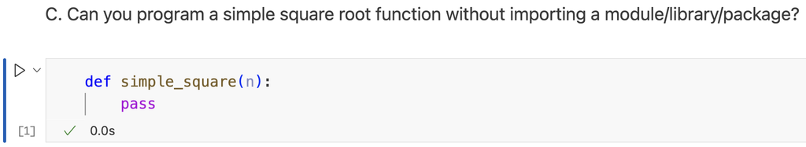

## Difference between Continue and Pass

| Feature | Continue | Pass |
| --- | --- | --- |
| Purpose | Skips the remainder of the current loop iteration and continues to the next iteration | Is a placeholder where a statement is required but pass does nothing |
| Effect on Loop Execution | Moves to the next iteration of the loop | Does nothing; execution moves to the next statement in the block |
| When to use | When skipping specific iterations in a loop | When a block of code is required but no operation needs to be performed |

## Typical Python Script (.py) Structure

- We are moving towards have the ability (or at least an understanding) of how to build a typical Python script.
- We will look all but part five next this week
- the fifth part next week

| Section | Purpose |
| --- | --- |
| (recommended) Module Docstring | Describes the purpose, help, instructions |
| (depends) Imports | Standard then Third-party then Local libraries |
| Global Constants | Store fixed values (e.g., API URLs file locations) |
| Functions | Define reusable actions |
| (perhaps 50%) Classes | For object-oriented programming |
| (recommended) Main Block (if **name** == ‘**main**’) | Ensures script runs only when executed directly |

# Activity

## Please gather together in small groups

- please make sure at least one member has a laptop
- for credit: minimum group size 3, maximum *optimal* group size 6 (but larger is OK)
- please introduce yourselves and try to learn a new name today
- please take a group photo, annotate with with names or add names as a comment during upload
- upload a photo individually for attendance credit

## What to do in your group (10-15 minutes)

- You could just socialize
- OR you could try the next problem, just see if you can calculate volume
- a .py, .ipynb, or .qmd (or Colab) will all work for a solution, doesn’t matter
- yes, you could ask your favorite ChatBot but give it an honest team try first

## From last time

Please try to write Python code that will correctly calculate volume for a sphere with radius 5 and also for radius 15. You might recall the bird age calculations from the previous lecture.

$$V = \frac{4}{3}\pi r^{3}$$

- You will need something to store the volume result V.
- and you will need a way to incorporate the radius (one at a time is easier than using both, I leave it up to you)
- You will need pi, To access pi, **math.pi** will work (pi is found in the math module of the Python Standard Library)
- Your result should display the calculated volume

```python
import math

# some code to calcuate volume
```

## Summary of Lecture 2

- Data Types (e.g., bool, int, float, str)
- Sequences (e.g., strings, ranges, lists, tuples)
- Data Structures (e.g., lists, tuples)
- Control Structures (e.g., if, elif, else)
- Some general observations about programming scripts

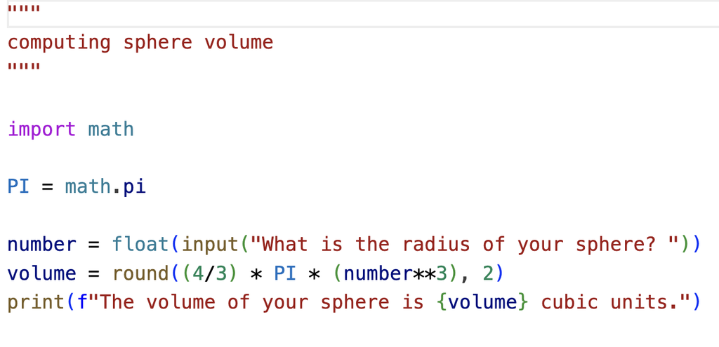

barebone but it works

# Lecture 3

## Today (Lecture 3)

- More mechanics on strings and lists
- More general advice on programming
- Task analysis
- Writing Functions in Python (probably lecture 4)
- Debugging strategies (probably lecture 4)
- Tuples, Sets, Dictionaries (probably lecture 4)

# More mechanics

## Recall Sequences - Common Operations

https://docs.python.org/3/library/stdtypes.html#common-sequence-operations

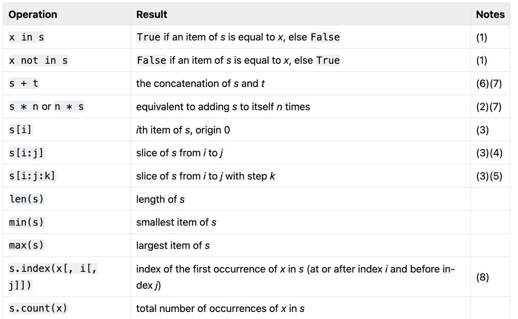

## String methods

See https://docs.python.org/3/library/stdtypes.html#string-methods

- Last week, we had a slicing example of a string
- Here are some commonly used string methods (functions written for strings)

| join | title |
| --- | --- |
| split | upper |
| strip | lower |
| find | replace |

- Python supports regular expressions (regex) for strings too, but we will examine these later in the quarter:

https://docs.python.org/3/library/text.html#textservices

## String methods example

- Setup
- Join
- Strip
- Find
- replace

```python
# Specify the location of the data

file_path = "gettysburg.txt"  # This is in the same directory as my script - update it with your actual file path

# Open and read the file, first split words using .split()
with open(file_path, "r", encoding="utf-8") as file:
    text = file.read()

    words = text.split()
# See https://docs.python.org/3/library/stdtypes.html#str.split
print(text[0:10])
print(words[0:10])
```

```
Four score
['Four', 'score', 'and', 'seven', 'years', 'ago', 'our', 'fathers', 'brought', 'forth']
```

```python
print('   '.join(text[0:10])) # exploded looking
print(' '.join(words[0:10]))
```

```
F   o   u   r       s   c   o   r   e
Four score and seven years ago our fathers brought forth
```

```python
print('   spacious   '.strip()+(' skies'))
print('www.example.com'.split('.')[1])
print('vlew@stat.ucla.edu'.split('@')[0])
```

```
spacious skies
example
vlew
```

```python
print(text.find('nation')) # string search

print(text[82:88])

print(f"is 'nation' in text? {'nation' in text}")

'nation' in words # all sequences can match but there is no find method for lists
```

```
82
nation
is 'nation' in text? True
```

```
True
```

```python
# str.replace(old, new, count=-1) -1 means all occurrences

print(text.replace("and", "AND"))
# print(words.replace("and", "AND"))
# won't work on a list object
```

```
Four score AND seven years ago our fathers brought forth on this continent, a new nation, conceived in Liberty, AND dedicated to the proposition that all men are created equal. Now we are engaged in a great civil war, testing whether that nation, or any nation so conceived AND so dedicated, can long…
```

## List methods

https://docs.python.org/3/library/stdtypes.html#mutable-sequence-types

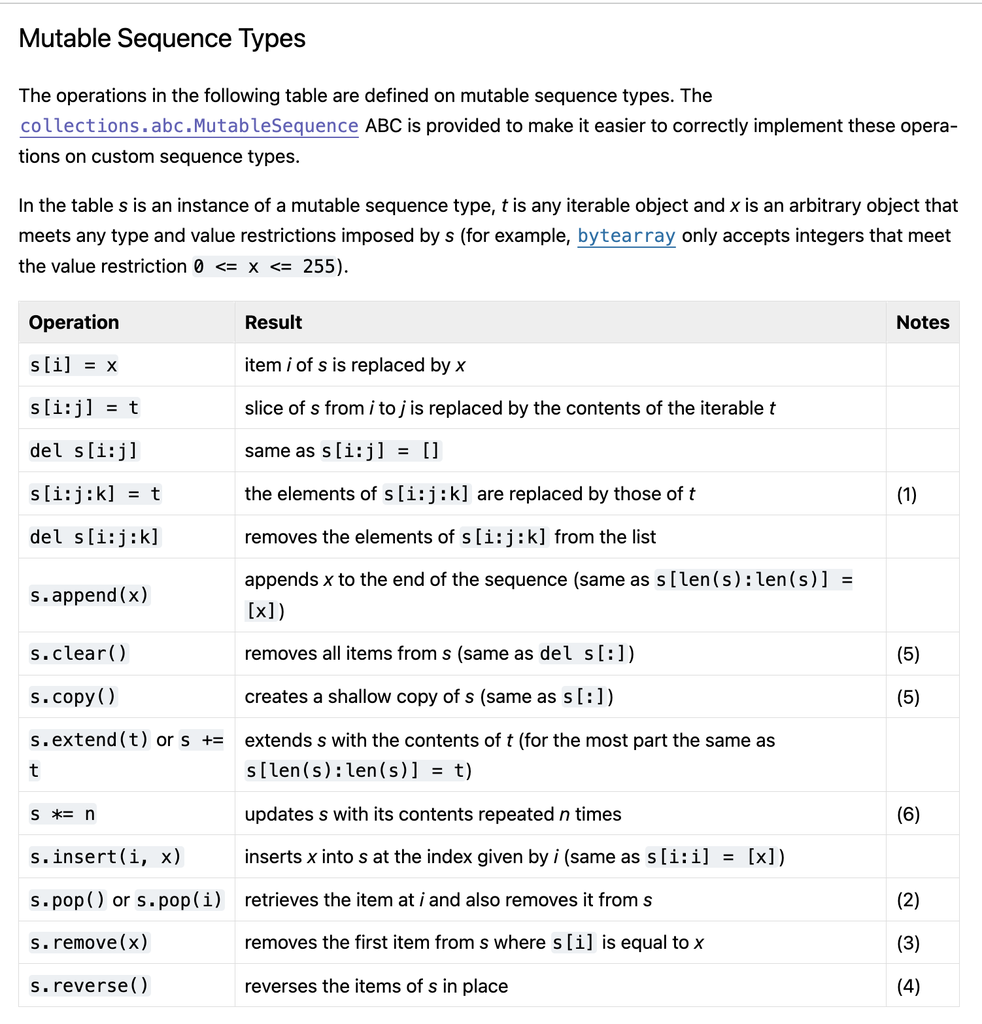

## List methods example

- Setup
- Slice
- Replacement
- Append & Insert

```python
file_path = "in_n_out_noquotes.csv"

# Open and read the file, remove newline, then split into separate words using .split()
with open(file_path, "r", encoding="utf-8") as file:
    text = file.read()
    fix1 = text.replace('\n', ',')
    words = fix1.split(',')

print(f"is words a list? {isinstance(words, list)}")
print(words[0:25])
```

```
is words a list? True
['name', 'address', 'city', 'state', 'zip', 'IRVINE', '4115 CAMPUS DRIVE', 'IRVINE', 'CA', '92612', 'CARLSBAD', '5950 AVENIDA ENCINAS', 'CARLSBAD', 'CA', '92008', 'ORANGE (TUSTIN & LINCOLN)', '2585 N. TUSTIN ST.', 'ORANGE', 'CA', '92865', 'MURRIETA', '39697 AVENIDA ACACIAS', 'MURRIETA', 'CA', '92563…
```

- Slicing is very fast because lists are contiguous in memory.
- We don’t want the first 5 so…

```python
data = words[5:] # just keeps the data part of the list

print(data[0:30])

print(data[0:30:5]) # names only
```

```
['IRVINE', '4115 CAMPUS DRIVE', 'IRVINE', 'CA', '92612', 'CARLSBAD', '5950 AVENIDA ENCINAS', 'CARLSBAD', 'CA', '92008', 'ORANGE (TUSTIN & LINCOLN)', '2585 N. TUSTIN ST.', 'ORANGE', 'CA', '92865', 'MURRIETA', '39697 AVENIDA ACACIAS', 'MURRIETA', 'CA', '92563', 'CORONA (AUTO CENTER DR.)', '450 AUTO CE…
['IRVINE', 'CARLSBAD', 'ORANGE (TUSTIN & LINCOLN)', 'MURRIETA', 'CORONA (AUTO CENTER DR.)', 'VACAVILLE']
```

Also a list comprehension

```python
# modify list values using "for"
for i in range(4, len(data), 5):  # Start at index 4, step by 5
    data[i] = int(data[i]) # we have converted the zip codes to numeric

# check
print(data[0:30])

# modify list values with a list comprehension plus enumerate
# enumerate(data) returns both the index (i) and its value (val)
data2 = ["California" if i in range(3, len(data), 5) else val for i, val in enumerate(data)]

print(data2[0:30])
```

```
['IRVINE', '4115 CAMPUS DRIVE', 'IRVINE', 'CA', 92612, 'CARLSBAD', '5950 AVENIDA ENCINAS', 'CARLSBAD', 'CA', 92008, 'ORANGE (TUSTIN & LINCOLN)', '2585 N. TUSTIN ST.', 'ORANGE', 'CA', 92865, 'MURRIETA', '39697 AVENIDA ACACIAS', 'MURRIETA', 'CA', 92563, 'CORONA (AUTO CENTER DR.)', '450 AUTO CENTER DR.…
['IRVINE', '4115 CAMPUS DRIVE', 'IRVINE', 'California', 92612, 'CARLSBAD', '5950 AVENIDA ENCINAS', 'CARLSBAD', 'California', 92008, 'ORANGE (TUSTIN & LINCOLN)', '2585 N. TUSTIN ST.', 'ORANGE', 'California', 92865, 'MURRIETA', '39697 AVENIDA ACACIAS', 'MURRIETA', 'California', 92563, 'CORONA (AUTO CE…
```

- also copy
- These sound like what they do.
- They modify in place

```python
names1 = data[0:15:5]
names1c = names1.copy() # correct way to make a copy
names1b = names1 # beware of this one
names2 = data[15:30:5]

print(names1)
print(names2)

names1.append(names2[1])

print(names1)

names1.insert(1, names2[0])

print(names1)
print(names1c)
print(names1b)
```

```
['IRVINE', 'CARLSBAD', 'ORANGE (TUSTIN & LINCOLN)']
['MURRIETA', 'CORONA (AUTO CENTER DR.)', 'VACAVILLE']
['IRVINE', 'CARLSBAD', 'ORANGE (TUSTIN & LINCOLN)', 'CORONA (AUTO CENTER DR.)']
['IRVINE', 'MURRIETA', 'CARLSBAD', 'ORANGE (TUSTIN & LINCOLN)', 'CORONA (AUTO CENTER DR.)']
['IRVINE', 'CARLSBAD', 'ORANGE (TUSTIN & LINCOLN)']
['IRVINE', 'MURRIETA', 'CARLSBAD', 'ORANGE (TUSTIN & LINCOLN)', 'CORONA (AUTO CENTER DR.)']
```

## (optional) More on List Comprehension

- from https://brilliant.org/wiki/list-comprehension/

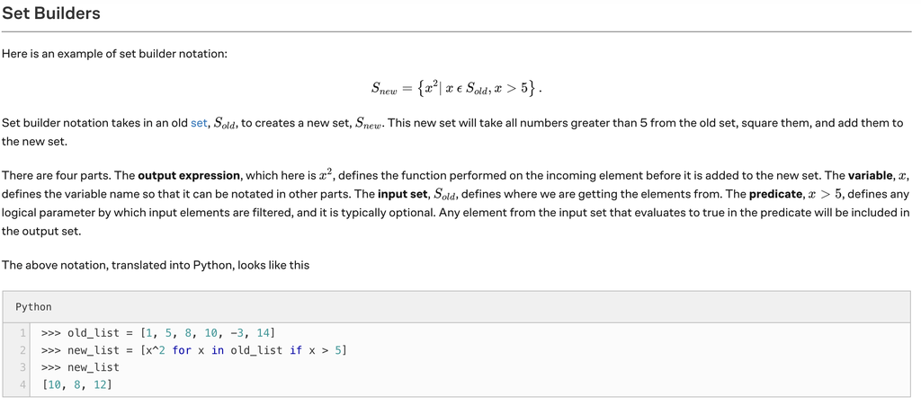

## Built-in functions

https://docs.python.org/3/library/functions.html

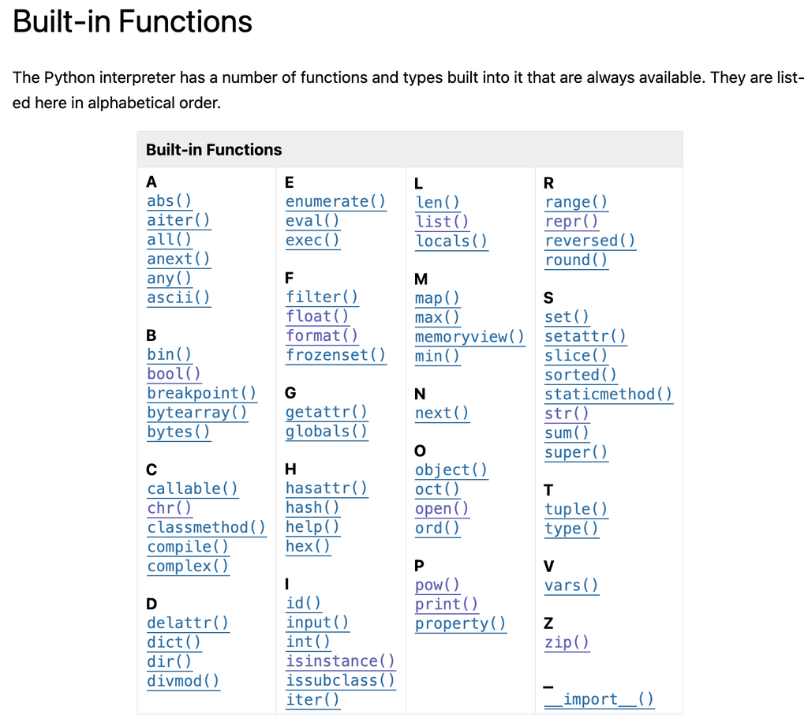

## Particularly Handy Built Ins

| print() | needs no explanation |
| --- | --- |
| len() | Used to obtain the size of lists, strings, etc. |
| range() | For loops/iteration |
| type() or isinstance() | When you need to check an object type |
| open() | Used to read and write files in core Python |
| sum() | sum a sequence |
| max() / min() | find the extremes with these |
| sorted() | used to order a sequence |
| enumerate() | Used to generate index-value pairs. |
| zip() | Used to pair elements from multiple iterables. |

# General Advice

## Moving from skills to synthesis

- This is challenging. Playing piano is not the same as composing music. Knowing spelling and the elements of English grammar is different from writing a movie script in English.
- Knowing how to write a for loop or a list comprehension is different from knowing how to extract information from a security video.
- Playing piano and knowing English grammar have use apart from synthesis.
- BUT there is no use for list comprehension and loops if we are unable to apply them to creating new solutions in the future.
- We learn to create by putting together our acquired skills to solve problems.

## Skills - the first part of Synthesis

- We start with the basic skills (working parts) “how to create an object”, “these are data structures”, “this is how a for loop works”, etc.
  - Synthesis requires knowing that there are different parts and what the parts can do
  - Knowing how to combine these parts to work together
  - Learning when & where to apply them (in different situations, different advantages/disadavntages)
  - Example - a **while** can be rewritten as an **if** which is preferred because generally **if** is faster. **while** repeatedly checks a condition for a given block of code; **if** checks once.

## From textbook to new & different problems

- We start to move away from solving textbook problems related to known examples
  - Synthesis requires us to break down unfamiliar problems into smaller parts
  - Then apply the skills we have acquired in new and creative ways.
  - With the goal of building a solution for the unfamilar piece by piece

## Suggestion: look for patterns

- Different problems have similarities.
  - Example: OLS regression provides the basic mathematical framework for understanding model training, loss functions, gradient descent, regularization, and feature transformations.
  - Neural networks are a generalization of OLS because it introduces non-linear transformations.

Synthesis involves seeing existing similarities and pairing more complex problems to pre-existing solutions.

## Have a Synthesis framework in mind

- Instead of resorting to brute force solutions to solve our problems, we aim to be more strategic in our approach to problem solving.
  - It starts with a clear understanding of the problem and its core elements.
  - Then moves towards breaking the larger problem down into subproblems (task analysis)
  - Programming/Assessing/Reviewing/Debugging the subproblems via function writing
  - Assembling the solved subproblems into a larger solution

## Example: Tic-Tac-Toe

- Suppose you were given an assignment (not in Stats 21) to program a tic-tac-toe game in Python.
- Where do you start?
  - Understand the problem, break it down
  - We need a board
  - then?
  - etc.

## Task Analysis

- Task analysis is a method of breaking down a complex task into smaller, sequential steps.
- This approach can make problem solving and learning more manageable with a systematic approach.
- Possible steps might be
  - Work out/on each step then (maybe re)order them.
  - Helps us to identify dependencies, inefficiencies or reveal opportunities for new solutions
  - Take the time to assess each step to develop a deeper understanding of the entire process. (Problem solving, debugging, revisions might happen here.)
  - Combine the steps to form a solution
- Success might be measured in time savings, productivity, meeting/exceeding goals.

## Transforming our steps into modular code

- Synthesis in Python requires designing *reusable* functions.
- Then combining these separate functions into classes (more on classes next week).
- Doing this comfortably involves some skill in applying the “separation of concerns”
  - where each step requires that we do one thing well

## Separation of Concerns

Structuring our solution by organizing it well. Let’s think about a data science workflow:

- Data Acquisition - Keep data acquisition code separate from analysis and modeling code. Write the code to obtain the data and save the code and data for further use.
- Data Cleaning and Preprocessing - In a different script or notebook, address missing values, encoding categorical variables, normalize numeric variables.
- Exploratory Data Analysis (EDA) - in a yet another notebook or script, explore the data and keep this separated from the data acquisition, cleaning, preprocessing etc.
- Feature Engineering - We might write functions in yet another script to create new features and keep them separate from data acquisition, cleaning, preprocessing, EDA, modeling.
- Model Training & Testing - yet another script or notebook where the actual modeling occurs.

## How Separation of Concerns can help

- Improves reproducibility (given the clarity of the solution).
- Helps collaboration because team members can work on the parts independently.
- Problems or improvements in one part should not affect the other parts
- Scales up well because it will be easier to extend models, preprocessors, etc.

# Writing Functions

## Functions

- Writing functions helps you with:
- 1
- 2
- 3
- 4
- 5
- 6
- Reusing code and its logic without copying and pasting
  - Without functions or scripts you might be copying and pasting a lot.
  - Writing functions allows you to encapsulate your logic, making your programming reusable and easier to maintain.
  - Define your logic once and call on it many times
- Efficiency and Automation
  - Python is excellent for automating repetitive tasks.
  - If you plan to work with data in the future or generate reports, presentations, etc. scripts can save time.
  - Example: Use Python to automate downloading data, cleaning the data, and then saving a formatted data analysis report.
- Debugging and Error Handling
  - Using functions makes identifying errors easier because typically a function should only do one task well (separation of concern?) - this helps us isolate issues/problems.
  - Programming our own functions and writing scripts lets us log errors and identify errors – helps us to track down errors in our code
- Scalability and Collaboration
  - Scripts and modularized code scale better for larger projects.
  - When working in a team, properly structured Python code is far easier to share and easier for others to understand.
- Gaining access to advanced features of Python
  - Many Python libraries (e.g., pandas, NumPy) assume you are able to define functions, use classes, and write scripts.
  - Some machine learning models often require defining custom data transformations via object-oriented programming
- Employability
  - Given the team-based work environment, many employers expect Python programmers to write structured, modular code
  - This means knowing how to write functions, using scripts, and implementing object-oriented programming (next week)
  - Programming languages come and go, but developing the underlying creative skills will serve you well.

## def

**This is the keyword for defining functions in Python**

- It must be followed by the function name and then a parenthesized list of formal parameters and a colon.
- The statements that form the body of the function start at the next line, and must be indented.

## Function examples

- 1
- 2
- 3
- 4
- Simplest function ever
- It’s a little silly but it has everything a function requires.

```python
def greet():
    return "Hello, World!"

print(greet())
```

```
Hello, World!
```

- Customizing the simplest function ever by adding the parameter “name” to the function.
- Parameters appear in the function definition

```python
def greet(name):
    return f"Hello, {name}"

her_name = "Jisoo" # the variable her_name, argument "Jisoo"

print(greet(her_name))
```

```
Hello, Jisoo
```

A little more complicated, there are two for loops here can you figure out what they do? (hint: identify the sequences first)

```python
def greet(names):
    output = [] # an empty list
    for name in names:
        #output.append(name) # this will work but the following is nicer
        output.append(f"Hello, {name}!")  # Adds "Hello"
    return output

bp= ["Jisoo", "Jennie", "Rosé", "Lisa"]

print(greet(bp))

for whatever in greet(bp):
    print(whatever)

#for _ in greet(bp): # _ is a wild card
    #print(_)
```

```
['Hello, Jisoo!', 'Hello, Jennie!', 'Hello, Rosé!', 'Hello, Lisa!']
Hello, Jisoo!
Hello, Jennie!
Hello, Rosé!
Hello, Lisa!
```

We are working with lists here, so a list comprehension makes sense followed by the join method for strings:

```python
def greet(names):
      return [f"Hello, {name}!" for name in names]

bp= ["Jisoo", "Jennie", "Rosé", "Lisa"]

print('\n'.join(greet(bp)))
```

```
Hello, Jisoo!
Hello, Jennie!
Hello, Rosé!
Hello, Lisa!
```

## Basic Function definition

- A basic function takes input and returns output.
- Most of our functions in Stats 21 will be basic

```python
nj = ['Hanni', 'Hyein', 'Haerin', 'Danielle', 'Minji']
# new input

print('\n'.join(greet(nj)))
```

```
Hello, Hanni!
Hello, Hyein!
Hello, Haerin!
Hello, Danielle!
Hello, Minji!
```

# Another Activity

## Task Analysis on a Pet Age Calculator

- Suppose a pet retailer has asked your team to program a Pet Age Calculator. They want a Python script that allows a user to input a pet’s age in years after selecting pet type (dog, cat, hamster, bird), and then converts the pet’s age to an estimated human equivalent. They have supplied the formulas:
  - 15 human years equals the first year of a medium-sized dog’s life. Year two for a dog equals about nine years for a human. And after that, each human year would be approximately five years for a dog
  - A cat’s first year is 15 human years, the second year adds 9 more, and each year after that is roughly equivalent to 4 human years
  - For a hamster, every 14 days of life is equivalent to a human year
  - Multiply bird age by 5 to estimate the human equivalent.
- Please suggest ways to break this down into a set of subproblems.
  - How should you structure the calculations? One big function for all four animals or one for each type?
  - Will you need other libraries to calculate age?
  - How should you capture the animal’s type and age? I haven’t taught this to you, but would your team want a GUI for users to input information? (…ask a chatbot?)

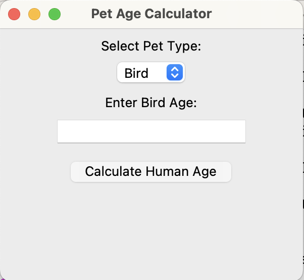

## A little more practice with def

- Dog
- Bird
- Together
- Try that dog age calculation

```python
def dog_to_human_years(dog_age):
    """15 human years equals the first year of a
    medium-sized dog’s life.
    Year two for a dog equals about nine years for a human.
    And after that, each human year would be
    approximately five years for a dog."""
    pass

# try it with different arguments
print(dog_to_human_years(17))
print(dog_to_human_years(-1))
print(dog_to_human_years("Waldo"))
```

- The example from Week 1

```python
def bird_to_human_years(bird_age):
    if bird_age <= 0:
        return "Age must be a positive number."
    return f"Your bird is {bird_age * 5} in human years"

bird_age = float(input("What is the bird's age? "))
print(bird_to_human_years(bird_age))
```

- Let’s put them together in one script, still basic
- But now a function that puts the two smaller ones together

```python
"""
should have a docstring about here
"""

def dog_to_human_years(dog_age):
    """15 human years equals the first year of a
    medium-sized dog’s life.
    Year two for a dog equals about nine years for a human.
    And after that, each human year would be
    approximately five years for a dog."""
    pass

def bird_to_human_years(bird_age):
    if bird_age <= 0:
        return "Age must be a positive number."
    return f"Your bird is {bird_age * 5} in human years"

def pet_age_calculator():
    """Calculates the human age of the pet based on the pet type and ask the user for input"""
    print("Welcome to the Pet Age Calculator!")
    print("Supported pets are: Dog, Bird")

    pet_type = input("What type of pet do you have? ").strip().lower()

    if pet_type in ["dog", "bird"]:
            pet_age = int(input(f"Enter your {pet_type}'s age in years: "))

            if pet_type == "dog":
                human_age = dog_to_human_years(pet_age)
            elif pet_type == "bird":
                human_age = bird_to_human_years(pet_age)

            print(f"Your {pet_type} is approximately {human_age} human years old!")
    else:
        print("Sorry, this calculator only supports dogs and birds.")

# run it
if __name__ == "__main__":
    pet_age_calculator()
```

## And still more practice with def

- while
- sorted
- sorted() 1
- sorted() 2
- From the Python documentation, example using while

```python
def fib(n):    # write Fibonacci series less than n
    """Print a Fibonacci series less than n."""
    a, b = 0, 1 # unpacking a tuple
    while a < n:
        print(a, end=' ')
        a, b = b, a+b
    print()

# Now call the function we just defined:
fib(2000)
```

- sorted() is a built-in function, at its simplest it just takes an iterable and does what you think it should do:

```python
spells = ["Expelliarmus", "Colloshoo", "Legilimens","Impedimenta", "Confundo", "Finite Incantatem","Incarcerous"]
nums = (8, 6, 7, 5, 3, 0, -9)

print(sorted(spells))
print(sorted(nums))
```

```
['Colloshoo', 'Confundo', 'Expelliarmus', 'Finite Incantatem', 'Impedimenta', 'Incarcerous', 'Legilimens']
[-9, 0, 3, 5, 6, 7, 8]
```

- But sorted() can take another function as an argument, this helps us transition into “higher order functions”
- sorted() will use that function to compute a value for each element before comparing them.

```python
spells = ["Expelliarmus", "Colloshoo", "Legilimens","Impedimenta", "Confundo", "Finite Incantatem","Incarcerous"]

sorted_spells = sorted(spells, key=len)
print(sorted_spells)
```

```
['Confundo', 'Colloshoo', 'Legilimens', 'Impedimenta', 'Incarcerous', 'Expelliarmus', 'Finite Incantatem']
```

- lambdas are anonymous functions (key= takes a function) they are small and inline
- syntax lambda argument(s): expression

```python
spells = ["Expelliarmus", "Colloshoo", "Legilimens","Impedimenta", "Confundo", "Finite Incantatem","Incarcerous"]

sorted_spells2 = sorted(spells, key=lambda spells: spells[::-1]) # what does[::-1] do?
print(sorted_spells2)
```

```
['Impedimenta', 'Finite Incantatem', 'Confundo', 'Colloshoo', 'Legilimens', 'Expelliarmus', 'Incarcerous']
```

## Takeaways

- Proposing a structure for getting started with writing functions in Python
- Know about the fundamental parts of Python
- Try a list comprehension
- Consider the basic function’s simple structure: “Input - Process - Output” and what needs to happen or what can happen at each step.
- Introduced the idea of using information from additional functions (e.g. lambda) which will bridge the gap from simple to complex.

## Probably a good time to stop

- If you haven’t grabbed a photo with a team, please do so.
- If you haven’t said “hello” to a classmate today, please reach out.
- Have wonderful day!